# Lab 08: Modeling Data 1

#The null hypothesis is that there is no difference in mean flipper lengths between the two penguin species (Chinstrap and Adelie). The mean difference under the null hypothesis is 0.

#The alternative hypothesis is that there is a significant difference in mean flipper lengths between the two penguin species (Chinstrap and Adelie). Since this is a two-tailed hypothesis, the mean difference could be either less than or greater than 0.

#Pines, Non-Parametric Test Q9

```r
veg = read.csv(here("data", "vegdata.csv"))
head(veg)
```

```
##   block plot date treatment birch pine fern
## 1     A   A3 1995   control     0    4  260
## 2     A   A7 1995   control     0    0  186
## 3     A   A4 1995   removed     8    8   46
## 4     A   A6 1995   removed     6   28    1
## 5     A   A5 1995     mixed     0    1  309
## 6     A   A8 1995     mixed     0    0  258
```

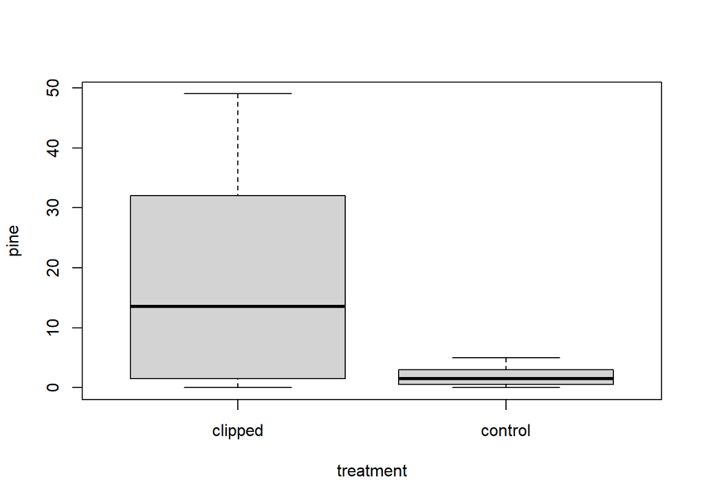

```r
#Q9 (2 pts.): What was the p-value? Show the R-code you used to find out.
#p-value = 0.05

#Use subset to create a new data frame with only clipped or control treatments
dat_tree = droplevels(subset(veg, treatment %in% c("control", "clipped")))

boxplot(pine ~ treatment, dat = dat_tree)
```

```r
#Conduct a Wilcoxon ranked sum test on the difference in means between the treatments.

wilcox.test(pine ~ treatment, data = dat_tree, alternative = "greater")
```

```
##
##  Wilcoxon rank sum test with continuity correction
##
## data:  pine by treatment
## W = 48, p-value = 0.05026
## alternative hypothesis: true location shift is greater than 0
```

#Pines, Bootstrap Q10-11

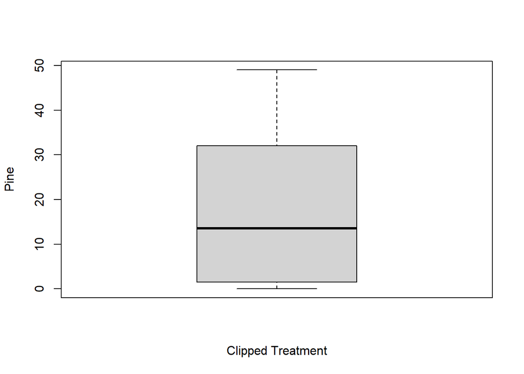

```r
sample1_tree <- droplevels(subset(dat_tree, treatment != "control"))
sample2_tree <- droplevels(subset(dat_tree, treatment != "clipped"))
#Note: I'm guessing there is an easier way to subset the data for each species for the two.boot function, but this is what I could come up with...

 boxplot(
    pine ~ treatment, data = sample1_tree,
    ylab = "Pine",
    xlab = "Clipped Treatment")
```

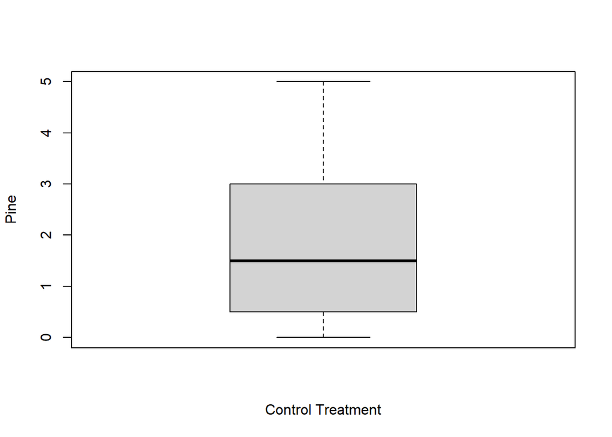

```r
 boxplot(
    pine ~ treatment, data = sample2_tree,
    ylab = "Pine",
    xlab = "Control Treatment")
```

```r
tree_boot = two.boot(sample1_tree$pine, sample2_tree$pine, boot_mean, R=10000)


str(tree_boot)
```

```
## List of 12
##  $ t0       : num 16
##  $ t        : num [1:10000, 1] 11.5 34.88 17.5 6.12 11.25 ...
##  $ R        : num 10000
##  $ data     : int [1:16] 11 0 16 3 49 17 0 47 4 0 ...
##  $ seed     : int [1:626] 10403 257 -1724915334 -275756177 -1016631820 -841833316 1767001660 -243640680 1058469866 -2026655783 ...
##  $ statistic:function (x, idx)
##  $ sim      : chr "ordinary"
##  $ call     : language boot(data = c(sample1, sample2), statistic = boot.func, R = R, strata = ind,      weights = weights)
##  $ stype    : chr "i"
##  $ strata   : num [1:16] 1 1 1 1 1 1 1 1 2 2 ...
##  $ weights  : num [1:16] 0.125 0.125 0.125 0.125 0.125 0.125 0.125 0.125 0.125 0.125 ...
##  $ student  : logi FALSE
##  - attr(*, "class")= chr "simpleboot"
##  - attr(*, "boot_type")= chr "boot"
```